# Visualisering af antal sagte ord

pmd

Før vi begynder, skal vi indlæse de udvidelsespakker til R, som vi vil benytte. Til sidst i denne kodeblok indlæser vi også de R funktioner vi har skrevet til dette projekt ved at `source` filen `src/p017-functions.R`.

```r
library(tidyverse)
library(here)
library(ndjson)
library(xslt)
library(fs)
library(ggplot2)

require(readr)  # for read_csv()
require(purrr)  # for map(), reduce()

source(here("src/p017-functions.R"))
```

# Indlæs data

Vi kan nu benytte en af P017 funktionerne til at indlæse alle de Holberg stykker, som vi har liggende i `test-data` mappen. Vi laver en tabel med navnet plays.

```r
here()
```

```
[1] "/home/baj/Projects/P017_R_Project"
```

```r
convert_TEI_to_JSONL(here("test-data"))
read_plays_jsonl(here("test-data")) -> plays
```

```
Parsing error on line 230
```

For at gøre det nemmere for os selv, starter vi med kun at se på ét skuespil “my_play” (fx Barselsstuen). Vi filtrerer ikke længere efter titel. Vi indlæser direkte fra JSON-filen! Forhåbentlig er “my_file” det eneste sted vi skal ændre for at lave visualiseringen for et andet skuespil :)

```r
my_file <- "test-data/De_u-synlige_mod_nc.jsonl"
my_play <- ndjson::stream_in(here(my_file)) %>% tibble()
my_play
```

| act | act_number | docTitle | index | scene | scene_number | speaker | speaker_stage | spoke | stage | title | type | year |
| --- | --- | --- | --- | --- | --- | --- | --- | --- | --- | --- | --- | --- |
| Første akt | 1 | De usynlige Komedie i 3 akter | 1 | Scene 1 | 1 | NA | NA | NA | Leander, Harlekin | De usynlige | 1 | (1731) |
| Første akt | 1 | De usynlige Komedie i 3 akter | 2 | Scene 1 | 1 | Harlekin | NA | Jeg kan sværge dyrt på, herre, at hvis jeg ikke havde hørt jeres røst, havde jeg umuligt kunne kende jer igen, sådan er I forandret på en måneds tid medens jeg har været borte. | NA | De usynlige | 4 | (1731) |
| Første akt | 1 | De usynlige Komedie i 3 akter | 3 | Scene 1 | 1 | Leander | NA | Ak, dig synes kun så, Harlekin. | NA | De usynlige | 4 | (1731) |
| Første akt | 1 | De usynlige Komedie i 3 akter | 4 | Scene 1 | 1 | Harlekin | NA | Da jeg rejste bort, herre, var I så fed som en forpagter, men nu ser I ikke anderledes ud end en vandrende ridder, en Don Quichot. Enten må herren have været syg, eller han må være forlibt. | NA | De usynlige | 4 | (1731) |
| Første akt | 1 | De usynlige Komedie i 3 akter | 5 | Scene 1 | 1 | Leander | NA | En af delene, Harlekin. | NA | De usynlige | 4 | (1731) |
| Første akt | 1 | De usynlige Komedie i 3 akter | 6 | Scene 1 | 1 | Harlekin | NA | Har herren da været syg? | NA | De usynlige | 4 | (1731) |
| Første akt | 1 | De usynlige Komedie i 3 akter | 7 | Scene 1 | 1 | Leander | NA | Nej, jeg har ikke. | NA | De usynlige | 4 | (1731) |
| Første akt | 1 | De usynlige Komedie i 3 akter | 8 | Scene 1 | 1 | Harlekin | NA | Så er herren da forlibt? | NA | De usynlige | 4 | (1731) |
| Første akt | 1 | De usynlige Komedie i 3 akter | 9 | Scene 1 | 1 | Leander | NA | Det kan nok være. | NA | De usynlige | 4 | (1731) |
| Første akt | 1 | De usynlige Komedie i 3 akter | 10 | Scene 1 | 1 | Harlekin | NA | I hvem er herren da forlibt? | NA | De usynlige | 4 | (1731) |

[output cut: 461 more lines]

# Gør data klar til visualisering

I et skuespil lader vi scene være den tidsmæssige udvikling. Så vi tæller hvad hver rolle siger for hver scene.

Hvor mange dialoger er der pr. scene?

```r
my_play %>%
  count(act_number, scene_number)
```

| act_number | scene_number | n |
| --- | --- | --- |
| 1 | 1 | 74 |
| 1 | 2 | 21 |
| 1 | 3 | 2 |
| 1 | 4 | 57 |
| 1 | 5 | 15 |
| 2 | 1 | 29 |
| 2 | 2 | 2 |
| 2 | 3 | 1 |
| 2 | 4 | 21 |
| 2 | 5 | 3 |

[output cut: 7 more lines]

## Tilføj scene indeks

Da vi ønsker at visualisere, hvor meget der tales over tid, har vi brug for et tal, der repræsenterer denne tid. Dette tal lader vi være et indeks for hver scene, som vi beregner i det følgende.

```r
my_play %>%
   group_by(act_number)  %>%
   summarise(scenes = max(scene_number)) %>%
   pull(scenes) %>% cumsum() -> act_length

act_length
```

```
[1]  5 11 17
```

```r
(number_of_scenes = sum(act_length))
```

```
[1] 33
```

Vi kan nu lave en funktion, som givet et aktnummer og scenenummer kan beregne den givne scenes nummer i sekvensen af alle scener

```r
calc_scene_index <- function(act_number, scene_number, act_length) {
   ifelse(is.numeric(scene_number),
      scene_number + ifelse(act_number==1, 0, act_length[act_number-1]),
      NA
   )
}
```

Vi bruger den som følger til at finde fx hvilket indeks den 4. scene i akt 3 har

```r
calc_scene_index(3, 4, act_length)
```

```
[1] 15
```

# Visualiser

For at visualisere hvem der siger hvor meget i de enkelte scener, skal vi erstatte det sagte med hvor mange ord, der bliver sagt. Dette gør vi ved at benytte funktionen `str_count(spoke, '\\w+')` som tager `spoke` og tæller hvor mange ord, der er i `spoke`. Denne værdi tilføjer vi i en ny kolonne, som vi kalder `n_spoken_words`.

```r
(my_play %>%
  mutate(n_spoken_words = str_count(spoke, '\\w+')) %>%
  select(n_spoken_words, everything()) -> tmp)
```

| n_spoken_words | act | act_number | docTitle | index | scene | scene_number | speaker | speaker_stage | spoke | stage | title | type | year |
| --- | --- | --- | --- | --- | --- | --- | --- | --- | --- | --- | --- | --- | --- |
| NA | Første akt | 1 | De usynlige Komedie i 3 akter | 1 | Scene 1 | 1 | NA | NA | NA | Leander, Harlekin | De usynlige | 1 | (1731) |
| 34 | Første akt | 1 | De usynlige Komedie i 3 akter | 2 | Scene 1 | 1 | Harlekin | NA | Jeg kan sværge dyrt på, herre, at hvis jeg ikke havde hørt jeres røst, havde jeg umuligt kunne kende jer igen, sådan er I forandret på en måneds tid medens jeg har været borte. | NA | De usynlige | 4 | (1731) |
| 6 | Første akt | 1 | De usynlige Komedie i 3 akter | 3 | Scene 1 | 1 | Leander | NA | Ak, dig synes kun så, Harlekin. | NA | De usynlige | 4 | (1731) |
| 37 | Første akt | 1 | De usynlige Komedie i 3 akter | 4 | Scene 1 | 1 | Harlekin | NA | Da jeg rejste bort, herre, var I så fed som en forpagter, men nu ser I ikke anderledes ud end en vandrende ridder, en Don Quichot. Enten må herren have været syg, eller han må være forlibt. | NA | De usynlige | 4 | (1731) |
| 4 | Første akt | 1 | De usynlige Komedie i 3 akter | 5 | Scene 1 | 1 | Leander | NA | En af delene, Harlekin. | NA | De usynlige | 4 | (1731) |
| 5 | Første akt | 1 | De usynlige Komedie i 3 akter | 6 | Scene 1 | 1 | Harlekin | NA | Har herren da været syg? | NA | De usynlige | 4 | (1731) |
| 4 | Første akt | 1 | De usynlige Komedie i 3 akter | 7 | Scene 1 | 1 | Leander | NA | Nej, jeg har ikke. | NA | De usynlige | 4 | (1731) |
| 5 | Første akt | 1 | De usynlige Komedie i 3 akter | 8 | Scene 1 | 1 | Harlekin | NA | Så er herren da forlibt? | NA | De usynlige | 4 | (1731) |
| 4 | Første akt | 1 | De usynlige Komedie i 3 akter | 9 | Scene 1 | 1 | Leander | NA | Det kan nok være. | NA | De usynlige | 4 | (1731) |
| 6 | Første akt | 1 | De usynlige Komedie i 3 akter | 10 | Scene 1 | 1 | Harlekin | NA | I hvem er herren da forlibt? | NA | De usynlige | 4 | (1731) |

[output cut: 461 more lines]

baj: Hov, vent lidt, Første Akt, Scene 1 har 74 linjer. Kan det passe? Første Akt, Scene 5 har fx kun 15… Prøv lige at tælle spoken words for Første Akt, Scene 1:

```r
tmp %>% filter(act_number == 1, scene_number == 1)
```

| n_spoken_words | act | act_number | docTitle | index | scene | scene_number | speaker | speaker_stage | spoke | stage | title | type | year |
| --- | --- | --- | --- | --- | --- | --- | --- | --- | --- | --- | --- | --- | --- |
| NA | Første akt | 1 | De usynlige Komedie i 3 akter | 1 | Scene 1 | 1 | NA | NA | NA | Leander, Harlekin | De usynlige | 1 | (1731) |
| 34 | Første akt | 1 | De usynlige Komedie i 3 akter | 2 | Scene 1 | 1 | Harlekin | NA | Jeg kan sværge dyrt på, herre, at hvis jeg ikke havde hørt jeres røst, havde jeg umuligt kunne kende jer igen, sådan er I forandret på en måneds tid medens jeg har været borte. | NA | De usynlige | 4 | (1731) |
| 6 | Første akt | 1 | De usynlige Komedie i 3 akter | 3 | Scene 1 | 1 | Leander | NA | Ak, dig synes kun så, Harlekin. | NA | De usynlige | 4 | (1731) |
| 37 | Første akt | 1 | De usynlige Komedie i 3 akter | 4 | Scene 1 | 1 | Harlekin | NA | Da jeg rejste bort, herre, var I så fed som en forpagter, men nu ser I ikke anderledes ud end en vandrende ridder, en Don Quichot. Enten må herren have været syg, eller han må være forlibt. | NA | De usynlige | 4 | (1731) |
| 4 | Første akt | 1 | De usynlige Komedie i 3 akter | 5 | Scene 1 | 1 | Leander | NA | En af delene, Harlekin. | NA | De usynlige | 4 | (1731) |
| 5 | Første akt | 1 | De usynlige Komedie i 3 akter | 6 | Scene 1 | 1 | Harlekin | NA | Har herren da været syg? | NA | De usynlige | 4 | (1731) |
| 4 | Første akt | 1 | De usynlige Komedie i 3 akter | 7 | Scene 1 | 1 | Leander | NA | Nej, jeg har ikke. | NA | De usynlige | 4 | (1731) |
| 5 | Første akt | 1 | De usynlige Komedie i 3 akter | 8 | Scene 1 | 1 | Harlekin | NA | Så er herren da forlibt? | NA | De usynlige | 4 | (1731) |
| 4 | Første akt | 1 | De usynlige Komedie i 3 akter | 9 | Scene 1 | 1 | Leander | NA | Det kan nok være. | NA | De usynlige | 4 | (1731) |
| 6 | Første akt | 1 | De usynlige Komedie i 3 akter | 10 | Scene 1 | 1 | Harlekin | NA | I hvem er herren da forlibt? | NA | De usynlige | 4 | (1731) |

[output cut: 64 more lines]

Vi er nu ved at være klar til at visualisere, hvem der siger hvor meget i fx Barselsstuen. Vi mangler bare at kombinere ovenstående kode

```r
my_play %>%
  # add a scene index for the x-axis
  rowwise() %>%
  mutate(scene_index = calc_scene_index(act_number, scene_number, act_length)) %>%
  # remove rows that are not dialogue
  filter(act != "", scene != "", !is.na(spoke)) %>%

  # select only the columns, that we are interested in
  select(scene_index, act_number, scene_number, speaker, spoke) %>%

  # add the number of spoken words
  mutate(n_spoken_words = str_count(spoke, '\\w+')) %>%
  # remove the spoken words
  select(-spoke) %>%

  # group the play in scene_index and speaker, ignoring the test
  group_by(scene_index, act_number, scene_number, speaker) %>%

  # Ensure that each speaker only appears once in each scene, i.e. sum the words spoken by each speaker
  # Lastly store the new data frame in a new reference for later use
  summarise(words = sum(n_spoken_words), act_number, scene_number) %>%
  distinct() -> my_summary
#print(barselsstuen_vis, n=60)
my_summary
```

| scene_index | act_number | scene_number | speaker | words |
| --- | --- | --- | --- | --- |
| 1 | 1 | 1 | Harlekin | 824 |
| 1 | 1 | 1 | Leander | 1299 |
| 2 | 1 | 2 | Den usynlige | 284 |
| 2 | 1 | 2 | Harlekin | 72 |
| 2 | 1 | 2 | Leander | 228 |
| 3 | 1 | 3 | Harlekin | 227 |
| 4 | 1 | 4 | Colombine | 196 |
| 4 | 1 | 4 | Harlekin | 612 |
| 5 | 1 | 5 | Colombine | 133 |
| 5 | 1 | 5 | Magdelone | 64 |

[output cut: 26 more lines]

Vi kan nu bruge `my_summary` som input til R’s visualiseringssystem, som hedder `ggplot` Nu er titlen på grafen fil-navnet, men den kan selvfølgelig ændres, hvis det ønskes.

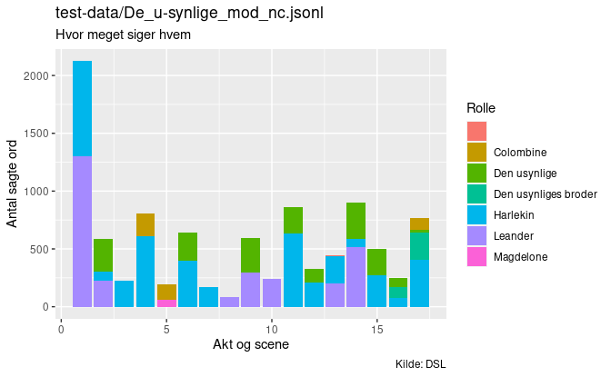

```r
my_summary %>%
  ggplot(aes(fill = speaker, y = words, x = scene_index)) +
    geom_bar(position="stack", stat="identity") +
    labs(
      title = my_file,
      subtitle = "Hvor meget siger hvem",
      caption = "Kilde: DSL",
      fill = "Rolle"
    ) +
  xlab("Akt og scene") +
  ylab("Antal sagte ord")
```

## Sammenlæg forskellige stavemåde af samme rolle

Først laver vi en liste over alle roller i fx Barselsstuen Husk at ændre titel

```r
print(my_summary %>%
        ungroup() %>%
  select(speaker) %>%
  distinct(speaker) %>%
  arrange(speaker), n=60)
```

| speaker |
| --- |
| Colombine |
| Den usynlige |
| Den usynliges broder |
| Harlekin |
| Leander |
| Magdelone |

Vi kan nu bruge to R funktioner: `if_else()` og `%in%`. Den første har tre argumenter. Det første er et logisk udtryk. Hvis dette udtryk er sandt, returneres resultatet af det andet argument. Hvis udtrykket er falsk, returneres resultatet af det tredje argument. Fx

```r
if_else(2==2, "Korrekt", "FAKE NEWS")
```

```
[1] "Korrekt"
```

```r
if_else("Trump"=="Klog", "Korrekt", "FAKE NEWS")
```

```
[1] "FAKE NEWS"
```

Vi vil også benytte funktionen `%in%`, som tjekker for om det der står til venstre er indeholdt i den liste der står til højre. Fx

```r
12 %in% c(1,2,3,4)
```

```
[1] FALSE
```

```r
12 %in% c(1, 2, 3, 12, 24)
```

```
[1] TRUE
```

Men det to funktioner, kan vi nu skrive denne kode Husk at disse ændringer er lavet til “Barselstuen”

```
'switch' is deprecated.
Use 'strip.position' instead.
See help("Deprecated")
```

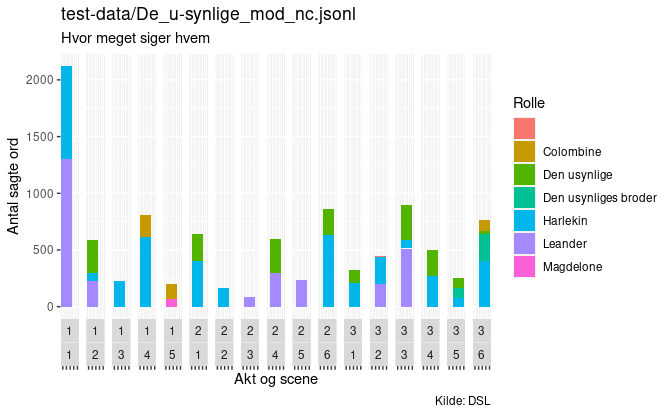

```r
my_summary %>%
  ungroup() %>%

  # count all versions of Leander as one
  mutate(
    speaker = if_else(speaker %in% c("Leander", "Leander på Knæ"), "Leander", speaker)) %>%

  # count all versions of Barselskvinden as one
  mutate(
    speaker = if_else(speaker %in% c("Barselskonen", "Barselskvinden", "Barselsqvinde"), "Barselskvinden", speaker)) %>%

  # Count all versions of kællingen as one
  mutate(
    speaker = if_else(speaker %in% c("Kælling", "Kællingen"), "Kællingen", speaker)) %>%

  ggplot(aes(fill = speaker, y = words, x = scene_index)) +
    geom_bar(position="stack", stat="identity", width = 30) +
    labs(
      title = my_file,
      subtitle = "Hvor meget siger hvem",
      caption = "Kilde: DSL",
      fill = "Rolle"
    ) +
  xlab("Akt og scene") +
  ylab("Antal sagte ord") +
  facet_wrap(act_number~scene_number, ncol=number_of_scenes, switch="x")+
  theme(axis.text.x=element_blank())
```